# Lab07: Introduction to the Bootstrap

```r
library(tidyverse)
library(patchwork)
theme_set(theme_minimal(base_size = 12))
```

Today, we’re going to return to the idea of using *simulation* to approximate sampling distributions. You’ll turn in a **rendered document** for this lab. (It may be easiest to render to .html, open in a browser, and then print to PDF).

Up until this point, we’ve generally followed the framework below when doing simulation:

1. Make assumptions about the *population parameters*
2. Generate a large number of *samples* from that *population*
3. Compute a *sample statistic* for each sample
4. Investigate the distribution of the sample statistics (*sampling distribution*).

This has worked well for our class, since we’ve been interested in the behavior of particular estimation or test procedures under known conditions. In the “real world”, however, we don’t want to have to assume anything about the population parameters in order to generate an approximate sampling distribution for a statistic. It turns out, there *is* a way we can do so! This is known as **bootstrap sampling**.

# The bootstrap

The name “bootstrap” comes from the phrase “pull yourself up by your bootstraps”, which generally means to succeed or elevate without any outside help. (Side note: the original phrase was originally used to describe something totally ludicrous, but at some point in the early 20th century it shifted to mean something attainable). While the origin of the name may have issues, it is fitting for how bootstrap sampling works: we can generate a sampling distribution using *only the sample that we actually observed*.

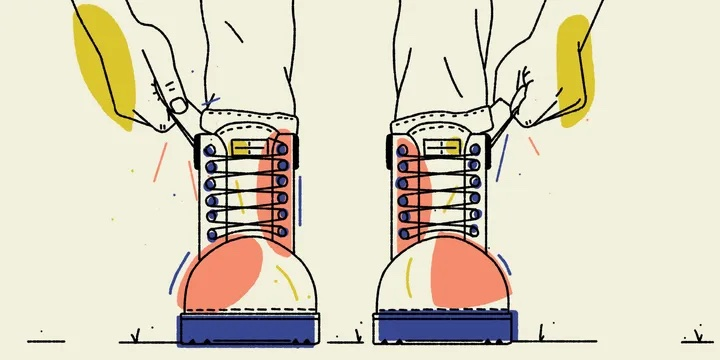

What this means is that we start with our original sample, and generate a bunch of new samples by sampling *with replacement* from our original sample. This is depicted visually below:

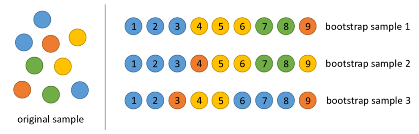

Visual representation of re-sampling with replacement using colored balls. Source: http://dx.doi.org/10.1016/B978-0-12-809633-8.20474-3

In math, assume we observe the data points $X_1, X_2, …, X_n$. Let $M_n$ be some sample statistic that we are interested in generating a sampling distribution for. First, we *sample with replacement* from our $n$ data points, leading to a new set of observations $X_1^{*(1)}, X_2^{*(1)}, ... X_n^{*(1)}$ (the * means that each observation is a resampled data point, and $(1)$ means that these observations make up the 1st bootstrap sample). Then, we do the same thing to generate $X_1^{*(2)}, X_2^{*(2)}, ... X_n^{*(2)}$. If we keep repeating this process, we end up with $B$ bootstrap samples:

$$X_1^{*(1)}, X_2^{*(1)}, ... X_n^{*(1)}$$

$$X_1^{*(2)}, X_2^{*(2)}, ... X_n^{*(2)}$$
$$X_1^{*(3)}, X_2^{*(3)}, ... X_n^{*(3)}$$

$$\vdots$$

$$X_1^{*(B)}, X_2^{*(B)}, ... X_n^{*(B)}.$$

Next, we compute the sample statistic for each bootstrap sample and call them $M_n^{*(1)}, M_n^{*(2)}, ..., M_n^{*(B)}$. We treat this set of $M_n^*$’s as the *sampling distribution*, which we can use to compute standard errors, confidence intervals, hypothesis tests, etc.

# Example where we know the solution

Let’s start with an example that we know how to work with. Let $X_1, ..., X_{25} \sim \text{Exp}(5)$. First, we generate this sample (`orig_x`) and will pretend that this is the only data that we have access to.

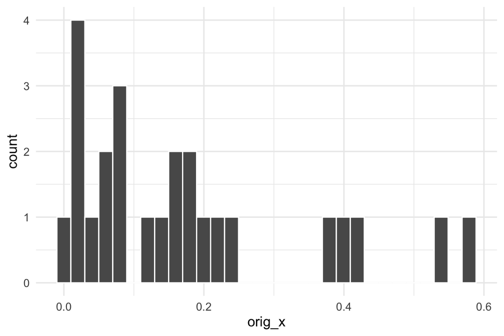

```r
set.seed(112223)

orig_x = rexp(25, rate = 5)

ggplot(tibble(orig_x = orig_x), aes(x = orig_x)) +
  geom_histogram(col = "white")
```

## Theoretical Sampling Distribution

**Question 1**

What is the *theoretical sampling distribution* of $\bar{X}$?

## Simulated sampling distribution using population information

The code below runs a simulation that we’ve essentially seen before, where 500 samples of size 25 are drawn from an Exp(5) distribution. For each sample, we store the sample mean and sample standard deviation.

```r
simulation_results = tibble(
  xbar = rep(NA, 500),
  s = rep(NA, 500)
)

for(ii in 1:500){
  x = rexp(25, rate = 5)
  simulation_results$xbar[ii] = mean(x)
  simulation_results$s[ii] = sd(x)
}
```

**Question 2**

Create a histogram of $\bar{X}$ and compute the mean and variance of the sampling distribution using the simulation. How does it compare to your answer from (1)?

## Bootstrap sampling distribution

In the simulation above, we *assumed* something about the population and were able to sample a bunch of possible samples. Now, we’ll do a *bootstrap* sampling procedure. Rather than drawing 500 samples of size 25 from the theoretical Exp(5) distribution, we *re-sample* from our original dataset using `sample(orig_x, size = 25, replace = TRUE)`. Try running this line of code a few times to get a sense for what it does.

```r
boot_results = tibble(
  xbar = rep(NA, 500),
  s = rep(NA, 500)
)

for(ii in 1:500){
  x = sample(orig_x, size = 25, replace = TRUE)
  boot_results$xbar[ii] = mean(x)
  boot_results$s[ii] = sd(x)
}
```

**Question 3**

Create a histogram of $\bar{X}_{boot}$ and compute the mean and variance of the sampling distribution using the bootstrap simulation How does it compare to your answer from (1) and (2)?

# Example where we *don’t* know the solution.

Where the bootstrap comes in especially handy is when we truly only have one sample. Let’s load in some real data:

```r
gss_email = read_csv("https://raw.githubusercontent.com/aluby/STAT61-F23/main/labs-activities/07-bootstrap/gss_email.csv")
```

This dataset comes from the 2016 [General Social Survey](https://gss.norc.org). One of the questions that was asked was “How much time do you spend on email weekly?” The answer, in hours, is given in the `email_hours` variable. The code below computes the mean and median of this variable.

```r
gss_email %>%
  summarize(
    mean_email = mean(email_hours),
    median_email = median(email_hours)
  )
```

```
# A tibble: 1 × 2
  mean_email median_email
       <dbl>        <dbl>
1       6.58            2
```

**Question 4**

Create a histogram of the `email_hours` variable. Does the mean or median seem like a better estimate for the average person?

**Question 5**

We’ve seen a version of the CLT for medians that looks something like: $\tilde{X} \sim N(\tilde{\mu}, \frac{1}{f_X(\tilde{\mu})}$, where $\tilde{X}$ is the sample median and $\tilde{\mu}$ is the population median. Why might we be uncomfortable using that formula in this setting? (*Hint:* What would we need to know about the population?)

Our goal is to build a confidence interval for the *median* of this population distribution. The code below simulates 500 bootstrap samples of the `email_hours` variable and stores the median of each bootstrap sample in the `boot_median` dataset.

```r
boot_median = tibble(
  median = rep(NA, 500)
)

for(ii in 1:500){
  x = sample(gss_email$email_hours, replace = TRUE)
  boot_median$median[ii] = median(x)
}
```

**Question 6**

Make a histogram of the bootstrap sampling distribution for the median, and compute the mean and standard deviation of this distribution. (Remember to use the `boot_median` data instead of, e.g., `simulation_results`!)

**Question 7**

The “CLT for medians” says the median may be approximately normal. Compute a confidence interval for $\tilde{X}$, the population median, using the *observed* mean and standard deviation of the sampling distribution with theoretical quantiles from the normal distribution. (e.g. similar in form to $\bar{X} \pm z_{\alpha/2} \frac{s}{\sqrt{n}}$.

**Question 8**

Compute a bootstrap confidence interval for $\tilde{X}$, the population median, using the *observed* 2.5 and 97.5 bootstrap percentiles. (*Hint:* Try `?quantile`) How does this interval compare to 7?

# Why does it work?

This is a *brief* introduction to the theory of why the bootstrap works. It’s all built upon an estimate for the CDF of the population probability distribution that we care about.

First, recall the definition of the CDF:
$$F_x(x_0) = P(X \le x_0)$$

In other words, $F_x(x_0)$ is the probability of the event $\{X \le x_0\}$. If we observe a sample of $X_1, ...., X_n \sim F_x$, a natural estimator for this probability is the observed proportion of observations where $\{X_i \le x_0\}$. So we could use:

$$\hat{F}_n(x_0) = \frac{\text{number of } X_i \le x_0}{\text{total number of observations}} = \frac{\sum_{i=1}^n \mathbb{I}(X_i \le x_0)}{n} = \frac{1}{n} \sum \mathbb{I}(X_i \le x_0)$$
as an estimator for $F_x$. This estimator is called the *empirical CDF*, or *ECDF*.

The plots below show the theoretical CDF for the N(0,1) distribution in orange, with the ECDF based on samples of size n=10, n=100, and n=1000. As the sample size gets bigger, the ECDF gets closer and closer to the true CDF.

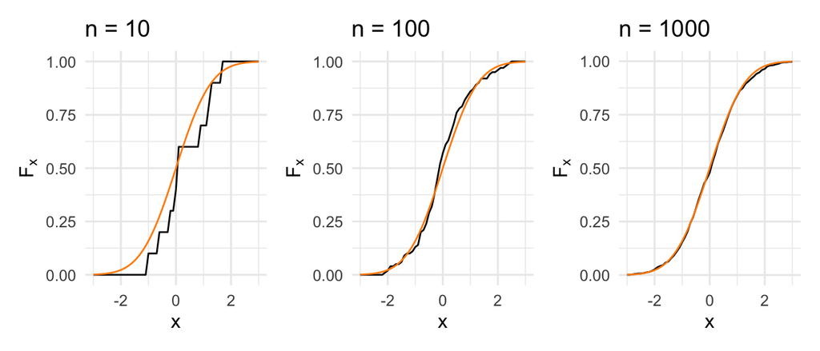

It can be shown that $\hat{F}_n(x)$ is an **unbiased** and **consistent** (among other things) estimator for $F_x$. The reason why bootstrap estimation works is that each bootstrap sample is an IID sample from $\hat{F}_n$. When $n$ is large, $\hat{F}_n$ is very close to $F$ and so any statistic that is based on $\hat{F}_n$ is very similar to the same statistic based on $F$! So re-sampling from our original sample, at least when $n$ is fairly large, results in a sampling distribution that is very similar to the theoretical sampling distribution, *even if we don’t know what the theoretical sampling distribution is* 🤯. (*Note:* this could be a great project idea to dive into!)

# Sources

- [Yen Chi Chen’s lecture notes](https://faculty.washington.edu/yenchic/19A_stat535/Lec10_bootstrap.pdf)
- [Maria Tackett’s course lab](https://www2.stat.duke.edu/courses/Fall19/sta199.001/labs/lab-08-bootstrap.html)